# 03 · Protein against phenotype

Every protein correlated with the ultrasound outcomes

Each protein’s pre-to-post change is correlated with the same leg’s change in muscle size and quality. The contrasts in `02_Differential` compare group means and have no per-leg outcome to correlate against.

The pooled analysis uses all 65 legs. The differential analysis uses the 32 participants with both legs and correlates the BFR minus HLRT difference in protein with the same difference in phenotype, so anything constant within a participant cancels.

```r
pacman::p_load(here, dplyr, tidyr, purrr, tibble, ggplot2, readr, readxl, writexl)

proteins <- readRDS(here("01_Preprocess", "02_Quantification", "c_data", "proteins.rds"))
phenotype <- read_csv(here("00_Input", "phenotype.csv"), show_col_types = FALSE)
```

With 3,042 proteins, about 152 reach p < 0.05 by chance, so results are read after BH within each analysis and outcome.

## Pairing

A leg needs both timepoints for a change score. S06’s left leg has T1 only, so it drops here and nowhere else.

```r
legs <- proteins$targets |>
  mutate(leg_id = paste(participant, leg, sep = "_")) |>
  select(leg_id, participant, leg, treatment, timepoint, sample_id) |>
  pivot_wider(names_from = timepoint, values_from = sample_id) |>
  drop_na(T1, T2) |>
  arrange(participant, treatment)
leg_pairs <- legs |>
  select(participant, treatment, leg_id) |>
  pivot_wider(names_from = treatment, values_from = leg_id) |>
  drop_na(BFR, HLRT)

delta <- proteins$E[, legs$T2] - proteins$E[, legs$T1]
colnames(delta) <- legs$leg_id
paired <- delta[, leg_pairs$BFR] - delta[, leg_pairs$HLRT]
colnames(paired) <- leg_pairs$participant
c(legs = ncol(delta), participants = ncol(paired), proteins = nrow(delta))
```

```
        legs participants     proteins
          65           32         3042
```

## Outcomes

Four ultrasound measures, each as a post-minus-pre change. Cross-sectional area measures size; echo intensity measures quality and falls as composition improves.

```r
leg_phenotype <- legs |>
  left_join(select(phenotype, -treatment), by = c("participant", "leg")) |>
  mutate(
    vl_csa = vl_csa_post_cm2 - vl_csa_pre_cm2,
    vl_echo = vl_echo_post_au - vl_echo_pre_au,
    rf_csa = rf_csa_post_cm2 - rf_csa_pre_cm2,
    rf_echo = rf_echo_post_au - rf_echo_pre_au
  )
outcomes <- c("vl_csa", "vl_echo", "rf_csa", "rf_echo")
paired_outcome <- map(set_names(outcomes), \(name) {
  value <- set_names(leg_phenotype[[name]], leg_phenotype$leg_id)
  value[leg_pairs$BFR] - value[leg_pairs$HLRT]
})
```

## Correlations

Neither change is expected to be normal, so every correlation is Spearman. Ties make `cor.test` fall back to its approximation and warn on every call, so the 24,336 warnings are suppressed.

```r
spearman_by_row <- function(values, outcome) {
  fits <- suppressWarnings(apply(values, 1, \(row) {
    test <- cor.test(row, outcome, method = "spearman")
    c(r = unname(test$estimate), p = test$p.value)
  }))
  tibble(
    protein = rownames(values), n = sum(!is.na(outcome)),
    r = unname(fits["r", ]), p = unname(fits["p", ])
  )
}
results <- map(set_names(outcomes), \(name) {
  bind_rows(
    pooled = spearman_by_row(delta, leg_phenotype[[name]]),
    differential = spearman_by_row(paired, paired_outcome[[name]]),
    .id = "analysis"
  )
}) |>
  list_rbind(names_to = "outcome") |>
  mutate(fdr = p.adjust(p, "BH"), .by = c(analysis, outcome)) |>
  mutate(gene = proteins$genes$Genes[match(protein, rownames(proteins$genes))]) |>
  relocate(analysis, outcome, protein, gene)
```

## What survives

```r
summary_table <- results |>
  summarise(
    proteins = n(), nominal = sum(p < 0.05), expected = round(n() * 0.05, 1),
    fdr_sig = sum(fdr < 0.05), best_fdr = signif(min(fdr), 3),
    .by = c(analysis, outcome, n)
  ) |>
  mutate(ratio = round(nominal / expected, 2)) |>
  arrange(analysis, outcome)
summary_table
```

| analysis | outcome | n | proteins | nominal | expected | fdr_sig | best_fdr | ratio |
| --- | --- | --- | --- | --- | --- | --- | --- | --- |
| differential | rf_csa | 32 | 3042 | 168 | 152.1 | 0 | 0.711 | 1.10 |
| differential | rf_echo | 32 | 3042 | 116 | 152.1 | 0 | 0.281 | 0.76 |
| differential | vl_csa | 32 | 3042 | 146 | 152.1 | 0 | 0.863 | 0.96 |
| differential | vl_echo | 32 | 3042 | 130 | 152.1 | 0 | 0.964 | 0.85 |
| pooled | rf_csa | 65 | 3042 | 134 | 152.1 | 0 | 0.361 | 0.88 |
| pooled | rf_echo | 65 | 3042 | 113 | 152.1 | 0 | 0.981 | 0.74 |
| pooled | vl_csa | 65 | 3042 | 183 | 152.1 | 0 | 0.460 | 1.20 |
| pooled | vl_echo | 65 | 3042 | 127 | 152.1 | 0 | 0.480 | 0.83 |

`ratio` divides the nominal count by that chance count. Near 1, the nominal hits are what 3,042 tests return when nothing is there, whatever the smallest p.

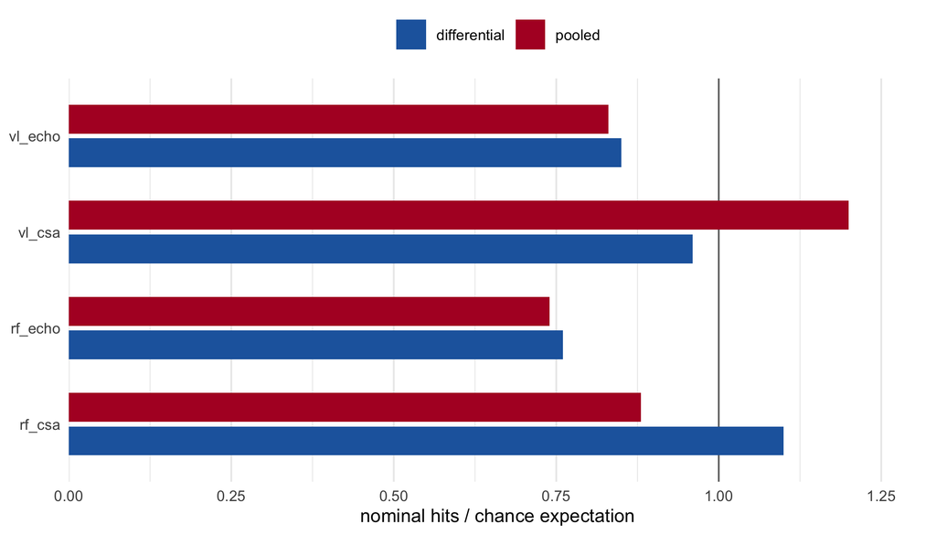

```r
ggplot(summary_table, aes(ratio, outcome, fill = analysis)) +
  geom_vline(xintercept = 1, linewidth = 0.4, colour = "grey40") +
  geom_col(position = position_dodge(width = 0.7), width = 0.6) +
  scale_fill_manual(values = c(pooled = "#B2182B", differential = "#2166AC"), name = NULL) +
  scale_x_continuous(expand = expansion(mult = c(0, 0.1))) +
  labs(x = "nominal hits / chance expectation", y = NULL) +
  theme_minimal(base_size = 10) +
  theme(panel.grid.major.y = element_blank(), legend.position = "top")
```

## Training hits among the leads

A training hit is a protein at BH < 0.05 in either Post-Pre contrast of `02_Differential`. The table counts training hits at nominal p per outcome against the count expected by chance, with a one-sided Fisher test.

```r
dep_matrix <- read_excel(
  here("02_Differential_Expression", "02_Differential", "c_data", "02_differential.xlsx"),
  "DEP_matrix"
)
training_hits <- dep_matrix |>
  filter(`BFR_Post-Pre_adj.P.Val` < 0.05 | `HLRT_Post-Pre_adj.P.Val` < 0.05) |>
  pull(protein)
training_overlap <- results |>
  mutate(training = protein %in% training_hits) |>
  summarise(
    training_hits = sum(training),
    nominal = sum(training & p < 0.05),
    expected = round(sum(training) * mean(p < 0.05), 1),
    fisher_p = signif(
      fisher.test(table(p < 0.05, training), alternative = "greater")$p.value, 2
    ),
    .by = c(analysis, outcome)
  ) |>
  arrange(analysis, outcome)
training_overlap
```

| analysis | outcome | training_hits | nominal | expected | fisher_p |
| --- | --- | --- | --- | --- | --- |
| differential | rf_csa | 130 | 8 | 7.2 | 0.430 |
| differential | rf_echo | 130 | 6 | 5.0 | 0.380 |
| differential | vl_csa | 130 | 5 | 6.2 | 0.760 |
| differential | vl_echo | 130 | 9 | 5.6 | 0.100 |
| pooled | rf_csa | 130 | 12 | 5.7 | 0.011 |
| pooled | rf_echo | 130 | 2 | 4.8 | 0.960 |
| pooled | vl_csa | 130 | 14 | 7.8 | 0.022 |
| pooled | vl_echo | 130 | 2 | 5.4 | 0.980 |

Both pooled CSA outcomes hold about twice the expected count; the other six sit at chance. Proteins that changed with training vary more across legs, which gives them more power in a pooled correlation.

```r
sheets <- list(
  summary = summary_table,
  training_overlap = training_overlap,
  correlations = arrange(results, fdr)
)
overview <- data.frame(
  sheet = names(sheets), rows = map_int(sheets, nrow), columns = map_int(sheets, ncol),
  description = c(
    "Hits against chance per outcome",
    "Training hits at nominal p against chance",
    "Spearman r, p and FDR per protein"
  )
)
out <- here("02_Differential_Expression", "03_Phenotype", "c_data")
write_xlsx(c(list(overview = overview), sheets), file.path(out, "03_phenotype.xlsx"))
```